# Exploratory Analysis

## Shaking Out The Facts

### Authors

Names of your team members: Brian Chiang, Nikola Cumic, Bonie Wang, Christine

### Date

Spring 2023

### Abstract

Our main question is to determine the continent with the highest number of earthquakes, the year with the most earthquakes, and the country with the most intense magnitudes. This question is important because understanding these patterns is crucial for disaster preparedness and risk assessment. To address the question, we will analyze an earthquake dataset, filtering and grouping the data by continent, year, and country, respectively.

### Keywords

Earthquake, Seismic, Informational, Accuracy, Visualization

### Introduction

A lot of data revolving around earthquakes is confined to datasets and not very accessible to people unfamiliar to data traversal. Our objective is to better visualize this data for people that wish to stay informed, but can’t take the time to sift through data about earthquakes. This also helps people understand the actual frequencies and magnitude of earthquakes, and why earthquakes are not something to be as feared as they are depicted in movies and on the news. This data also has a unique column that goes over what citizens of a certain area felt like the magnitude of the earthquake was, this information if taken into account could also lower peoples worries of earthquakes and keep them more informed on earthquake impacts. Another good thing for people to understand about earthquakes are other variables that happen alongside the event and how they effect the surrounding environment, since many people don’t understand the aftermath/effects earthquakes bring(that is why we are also focusing on how many of these earthquakes cause tsunamis, or damage building around them). We intend to put a more clear understanding of these natural phenomena in order to better reassure people and to inform.

#### Research Questions

1. Continent with most earthquakes?
2. What year had the most earthquakes?
3. Number of earthquakes over the years(trend)
4. Country with the most intense magnitudes of earthquakes
5. Which Country had the most accurate estimated of intensities?

### Related Work

The topic of earthquake data visualization has gained significant attention in recent years due to the increasing frequency and severity of earthquakes worldwide. One of the challenges associated with earthquake data is its vastness and complexity, making it difficult for the public to comprehend. To address this issue, researchers have developed various tools and techniques to visualize earthquake data in an accessible and understandable format.

One example of related work is the Earthquake Visualization Project developed by the IRIS Consortium, which provides a comprehensive database of earthquake data and various visualization tools to analyze the data. The project offers interactive maps and timelines that enable users to explore earthquake data by location, magnitude, and depth. (IRIS Consortium, 2021)

Another example is the Global Earthquake Explorer (GEE), developed by the US Geological Survey, which provides real-time seismic data and visualization tools for earthquakes and other geophysical events. GEE allows users to analyze earthquake data in various formats, including maps, waveforms, and cross-sections. (USGS, 2021)

Additionally, a research paper by Fokaefs et al. (2020) explores the use of virtual reality (VR) technology to visualize earthquake data. The authors developed a VR application that allows users to explore earthquake data in a 3D environment, providing a more immersive and interactive experience than traditional visualization methods.

Overall, the research in earthquake data visualization has provided various tools and techniques to make earthquake data more accessible and understandable to the public. These efforts can aid in educating individuals about the frequency and magnitude of earthquakes and help to alleviate fear surrounding these natural events.

#### References

IRIS Consortium. (2021). Earthquake Visualization Project. Retrieved from https://www.iris.edu/hq/inclass/interactive/earthquake_visualization_project USGS. (2021).

Global Earthquake Explorer. Retrieved from https://www.usgs.gov/natural-hazards/earthquake-hazards/real-time-seismicity/global-earthquake-explorer-gee Fokaefs, M., Iosifidis, T., & Tzovaras, D. (2020).

Virtual reality visualization of earthquake data. IEEE Transactions on Visualization and Computer Graphics, 26(4), 1824-1834.

### The Dataset

> Where did you find the data? Please include a link to the data source

https://www.kaggle.com/datasets/warcoder/earthquake-dataset

> Who collected the data?

Chirag Chauhan

> How was the data collected or generated?

The data was collected through seismic sensors near/at the locations of earthquakes from all around the world. The data is a massive collaboration between seismic stations around the world by having their data gathered and shared in one location.

> Why was the data collected?

For scientists to see trends in earthquakes and fault lines

> How many observations (rows) are in your data?

782 rows

> How many features (columns) are in the data?

19 columns

> What, if any, ethical questions or questions of power do you need to consider when working with this data?

Data privacy - It includes information about the location and/or damage to the area by the earthquake. We should consider the affected individuals before using the data.

> What are possible limitations or problems with this data? (at least 200 words)

One another main limitation is that the accuracy of earthquake data can be affected by the changes of monitoring technology and techniques over time. As the newest methods for detecting and measuring earthquakes are developed, the historical data may become less accurate and reliable compared to the more recent data.

### Implications

The findings of this analysis can have significant implications for technologists, designers, and policymakers working in the field of disaster management, infrastructure development, and risk assessment.

For technologists, understanding the continent, year, and country with the highest earthquake occurrences and magnitudes can guide the design and development of robust and resilient infrastructure. This knowledge can inform the implementation of advanced technologies such as early warning systems, structural engineering innovations, and geospatial mapping tools to enhance earthquake preparedness and response.

Designers can leverage the insights gained from this analysis to develop earthquake-resistant architectural designs and urban planning strategies. By considering the specific regions with high earthquake activity, designers can integrate seismic safety measures into buildings, bridges, and critical infrastructure to minimize the impact of earthquakes on human lives and property.

Policymakers can utilize the information about earthquake patterns and intensities to formulate effective disaster management strategies, allocate resources, and prioritize investments in vulnerable regions. This analysis can guide policymakers in implementing regulations and building codes that enforce seismic resilience standards, ensuring that infrastructure projects adhere to seismic safety guidelines.

### Limitations & Challenges

Some challenges we might need to address when diving deeper into our project idea is what information is truly helpful for people to know, what information is best to display and focus on if our main goal is to inform, and dispel concerns. Our challenges will mostly focus around the way we decide what data is important and what is not(a lot like the book we are reading for this class). We will need to look into how certain data can be used to reach our goal considering there is a lot of data. Some limitations we might face is how we will limit our data(whether that be to a certain country or continent) and if we want to cross-examine data from other sources, how will we do that efficiently and reasonably? We need to understand our focus group even more in order to better sift through data and better reach our intended audience. Another limitation will be how accurate the data is or if all seismic sensors record even data.

### Table

| magnitude | date_time | reported intensity | estimated intensity | alert | tsunami | significance | latitude | longitude | location | continent | country |
| --- | --- | --- | --- | --- | --- | --- | --- | --- | --- | --- | --- |
| 7.0 | 22-11-2022 02:03 | 8 | 7 | green | 1 | 768 | -9.7963 | 159.5960 | Malango, Solomon Islands | Oceania | Solomon Islands |
| 6.8 | 22-09-2022 06:16 | 8 | 7 | yellow | 1 | 1179 | 18.3300 | -102.9130 | Aguililla, Mexico | North America | Mexico |
| 7.6 | 19-09-2022 18:05 | 9 | 8 | yellow | 1 | 1799 | 18.3667 | -103.2520 | Aguililla, Mexico | North America | Mexico |
| 6.9 | 18-09-2022 06:44 | 9 | 9 | yellow | 1 | 887 | 23.1444 | 121.3070 | Yujing, Taiwan | Asia | Taiwan |
| 6.5 | 17-09-2022 13:41 | 7 | 7 | green | 1 | 756 | 23.0290 | 121.3480 | Lugu, Taiwan | Asia | Taiwan |
| 7.6 | 10-09-2022 23:47 | 8 | 8 | yellow | 1 | 965 | -6.2237 | 146.4710 | Kainantu, Papua New Guinea | Oceania | Papua New Guinea |
| 6.6 | 05-09-2022 04:52 | 9 | 8 | orange | 0 | 1043 | 29.7263 | 102.2790 | Kangding, China | Asia | People's Republic of China |
| 7.0 | 27-07-2022 00:43 | 9 | 8 | yellow | 1 | 1351 | 17.5978 | 120.8090 | Bantay, Philippines | Asia | Philippines |
| 6.5 | 08-06-2022 00:55 | 3 | 2 | green | 0 | 653 | -9.0618 | -71.1647 | Tarauacá, Brazil | South America | Brazil |
| 7.2 | 26-05-2022 12:02 | 7 | 5 | green | 1 | 876 | -14.8628 | -70.3081 | Azángaro, Peru | South America | Peru |

[output cut: 86 more lines]

### Chart 1

> Describe why you chose this chart and what information it reveals

This chart was chosen as a means to let people truly see where earthquakes of measurable scale occur. This not only inform people about areas that see more heavy earthquake activity, but also help people realize how many earthquakes happen and how many go unnoticed. It’s a way to put some people at ease, while informing others that not all earthquakes are those intense ones seen in movies. The reason for choosing this form for the chart is because it provides a great visual understanding of earthquake locations and their intensities in a certain area.

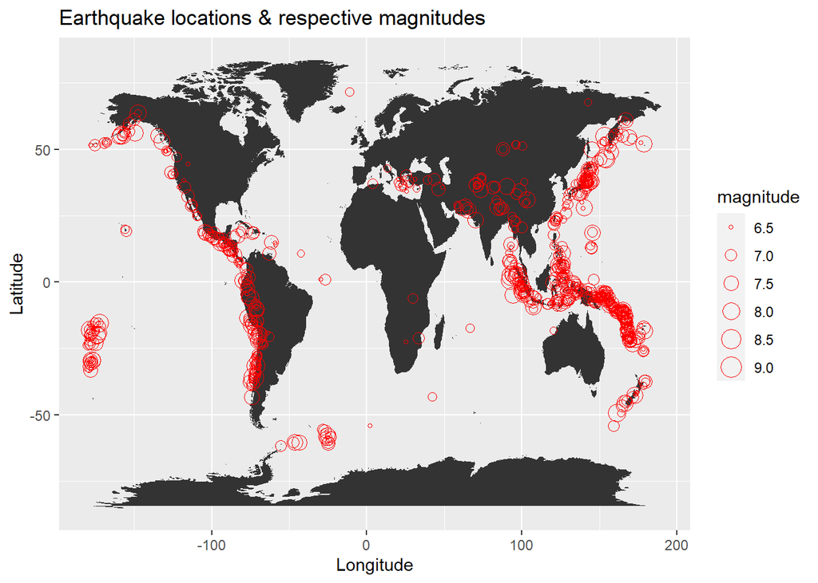

### Chart 2

> Describe why you chose this chart and what information it reveals

A bar chart was used to illustrate the top eight countries with the highest accurate predicted intensities. A bar chart is a useful tool for comparing numbers across multiple categories, in this example, countries. We can simply examine and compare the average accuracy numbers for each country by using a bar chart. The average accuracy is shown by the height of each bar, allowing us to readily identify the countries with the highest accuracy. From this graph, the countries are ranked based on their average accuracy values, with Tajikistan having the highest average accuracy and Mexico having the lowest among the top 8 countries. In addition, the length of each bar allows us to compare the average accuracy values between countries. We can observe the variations in accuracy levels and identify the countries with relatively higher or lower accuracy.

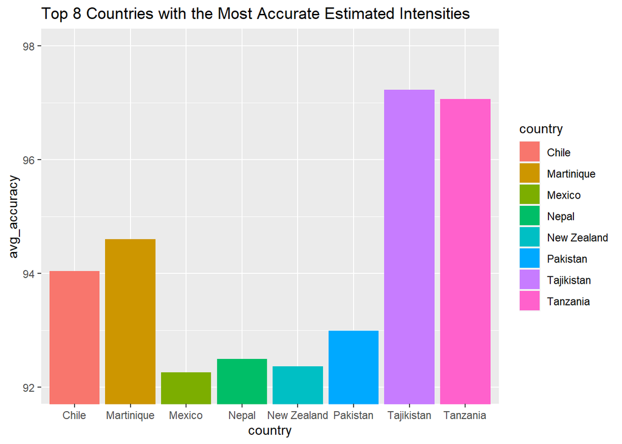

### Chart 3

> Describe why you chose this chart and what information it reveals

The reason this chart was chosen to depict the # of earthquakes that cause tsunami’s was due to how the visual created a way for people to better understand not only how many earthquakes cause water related events, but also to understand where those sort of natural disaster truly happen(someone living in America should be less worried about earthquake related water disasters happening then someone in the Philippines).

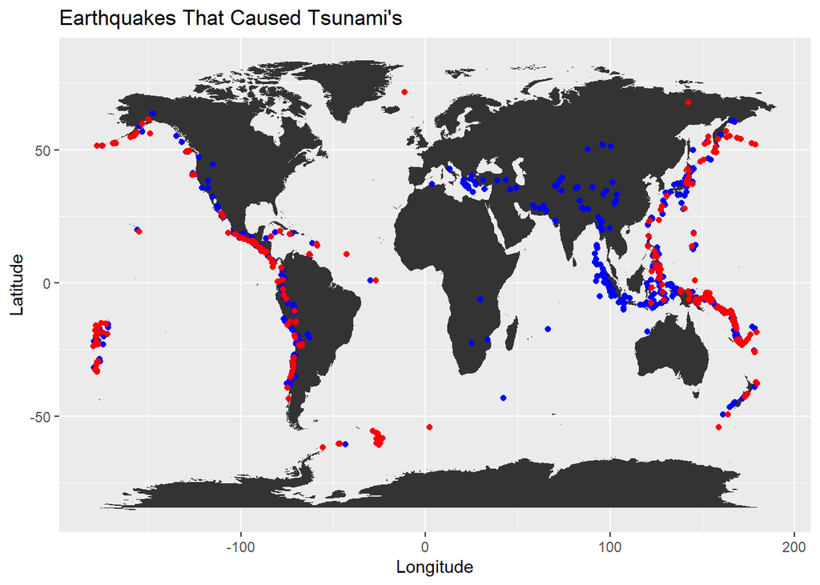